# Fine-tuning a model on a negation scope detection task

Within each word group, majority voting is applied to decide the final prediction and gold label for the word. For example, if a word split into tree subwords has predictions [0, 1, 0], the majority prediction 0 will be chosen as the final prediction for the word. This logic ensures a consistent word-level label and consider cases when the subword predictions differ.

For example, a tokenized sentence with the subwords and their corresponding predictions:

Subwords: ['dis', '##agree', '##ment']

Word ids: [9, 9, 9]

Predictions: [0, 1, 1]

The subwords 'dis', '##agree' and '##ment' belong to the same word (word id: 9). The predictions for these subwords are [0, 1, 1]. Using majority voting, the final word-level prediction for 'disagreement' becomes 1.

This process ensures that the final predictions is in word level required by the task and filtering out irrelevant tokens.

```python
# print(processed_predictions[0])
# print(processed_gold[0])
# print(test_aug[0])
special_tokens = tokenizer.all_special_tokens
special_tokens
```

```
['[UNK]', '[SEP]', '[PAD]', '[CLS]', '[MASK]']
```

```python
gold = processed_gold
pred = processed_predictions
gold = [1 if item == 1 else 0 for sublist in gold for item in sublist]
pred = [1 if item == 1 else 0 for sublist in pred for item in sublist]
```

```python
def output_tsv(input_file, output_file, prediction, gold):
    """
    Writes negation scope predictions to an output TSV file.

    Parameters:
    input_file : str
        Path to input TSV file.
    output_file : str
        Path to output TSV file.
    prediction : list of list of int
        Predicted negation labels (1 for negation, 0 for non-negation).

    Returns: None
    """
    outfile = open(output_file, "w")

    # prediction
    # flat_list = [token for sentence in prediction for token in sentence]

    index = 0
    for line in open(input_file, "r"):
        if len(line.rstrip("\n").split()) > 0:
            if prediction[index] == 1:
                # this only works because index 3 is the base word
                data = line.split()[3]
            else:
                data = "_"
            if gold[index] == 1:
                # this only works because index 3 is the base word
                gold_d = line.split()[3]
            else:
                gold_d = "_"
            outfile.write(line.rstrip("\n") + "\t" + data + "\t" + gold_d + "\n")
            index += 1

    outfile.close()
```

```python
output_tsv(dup_test,'./prediction.tsv',pred,gold)
```

```python
def evaluate_file(tsv_file):
    """
    Evaluate a TSV file with gold and predicted labels by creating a classification report and Confusion Matrix.

    :param tsv_file: Path to the TSV file.
    """

    columns = [
        "chapter_name",
        "sentence_number",
        "token_number",
        "word",
        "lemma",
        "part-of-speech",
        "syntax",
        "cue",
        "scope",
        "event",
        "pred",
        "gold"
    ]

    df = pd.read_csv(tsv_file, sep="\t", header=None, names=columns)

    y_true = df["scope"].apply(lambda x: 0 if x == "_" else 1).tolist()
    y_pred = df["pred"].apply(lambda x: 0 if x == "_" else 1).tolist()

    report = classification_report(
        y_true, y_pred, target_names=["Out of Scope", "In Scope"], digits = 3
    )
    print("Classification Report:")
    print(report)

    cm = confusion_matrix(y_true, y_pred)
    print("Confusion Matrix:")

    target_names = ["Out of Scope", "In Scope"]
    disp = ConfusionMatrixDisplay(
        confusion_matrix=cm, display_labels=target_names
    )
    disp.plot(cmap="magma")
    plt.title("Confusion Matrix")
    plt.xlabel("Predicted Labels")
    plt.ylabel("True Labels")
    plt.show()
```

```
Classification Report:
              precision    recall  f1-score   support

Out of Scope      0.938     0.953     0.946      3884
    In Scope      0.897     0.866     0.881      1826

    accuracy                          0.925      5710
   macro avg      0.917     0.910     0.913      5710
weighted avg      0.925     0.925     0.925      5710

Confusion Matrix:
```

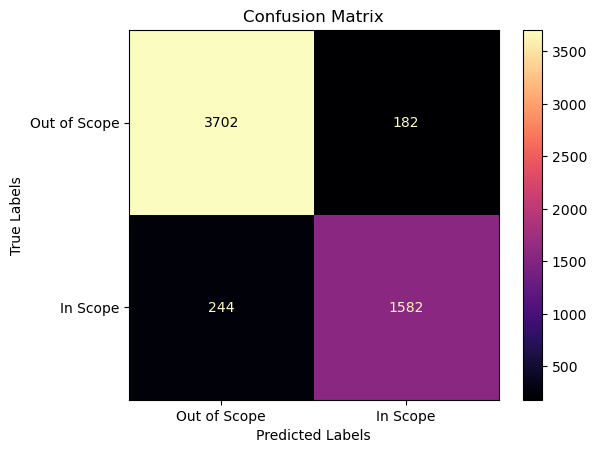

```python
evaluate_file("prediction.tsv")
```

**Model's preformance and comparison**

My BERT model with a random seed of 99 shows strong overall performance in the task of token-level negation scope detection.The macro average f1 score is 0.913, and the weighted f1 score is 0.925, showing that the model performs consistently well across the dataset.

My BERT model with a random seed of 99 shows a significant improvement over my previous CRF model in Assignment 2. The BERT model achieves an f1 score of 0.946 for "Out of Scope" and 0.881 for "In Scope," compared to the CRF model's 0.90 and 0.79 respectively. This could indicate that the BERT model is more capable of understanding contextual information through its transformer architecture, which the CRF model lacks. Notably, the 0.79 recall score for "In Scope" in the CRF model is lower than the 0.866 recall score in the BERT model, same pattern is noticed in the "In Scope" precision score (0.79 and 0.897), showing that BERT identifies more true positives in this category while also reducing false positives.

When compared to my teammates' BERT models, my model slightly lags in certain metrics. For example, my model's macro average f1 score of 0.913 is slightly lower than the models with seeds 71, 127, and 4294967294, which achieve macro average f1 scores of 0.916, 0.916, and 0.917 respectively. My model also has the lowest precision for the "In Scope" class (0.897), compared to the models with seeds 71 (0.920), 127 (0.910), and 4294967294 (0.915). On the other hand, the highest "In Scope" recall comes from my model (0.866). With reference to the confusion matrices, number of false positive cases in my model is the highest among all the others. The reason behind these differences could be that my model is with a random seed that makes it more effective at correctly identifying cases where a token truly belongs to the "In Scope" class, at the expense of slightly higher false positives. However, my model shows balanced performance, with relatively stable precision and recall, and a strong weighted f1 score of 0.925.

On the other hand, the results of my BERT model could also be compared to the scope token evaluation of the shared task, since my token-level evaluation measure align closely with the Scope Tokens F1 measure. The systems with best performance in the closed track of the shared task reported f1 scores of approximately 0.83 to 0.85, depending on the differences of system (e.g. UiO1 system reported 0.8526 and UiO2 system reported 0.8373 for scope tokens). My model outperforms these systems in this token-level evaluation context. When looking at the open track Scope Tokens f1 scores, the best-performing system, UiO2, achieved a Scope Tokens f1 score of 0.8220. This indicates that my BERT model significantly outperforms the open track system with the highest score by nearly 6 percentage points. Those differences may due to BERT's nature of being pre-trained on large corpora that enable it to be more sensitive to contextual relationships, and also due to the fact that the shared task don't have gold cue labels and have to detect them.

## Scope Detection Task on Standalone Sentences

```python
# save the model
# model.save_pretrained("BERT_model")
```

```python
# save the tokenizer
# tokenizer.save_pretrained("Tokenizer")
```

[output not shown]

```python
# load the model and the tokenizer
# assuming that the model and tokenizer folders are in the same directory as this notebook
pokemon_model = AutoModelForTokenClassification.from_pretrained("BERT_model")
pokemon_tokenizer = AutoTokenizer.from_pretrained("Tokenizer")
```

```python
# save the trainer
# with open("BERT_trainer.pkl", "wb") as trainer_file:
#     pickle.dump(trainer, trainer_file)
```

```python
# run this function before loading the trainer
def compute_metrics(p):
    """
    Compute evaluation metrics for token classification predictions.

    This function calculates precision, recall, f1 score, and accuracy for token-level
    predictions. It handles special tokens by removing ignored indices (-100) before computation.

    Argument:
        p (tuple): A tuple containing:
            - predictions (numpy.ndarray): model predictions with shape (batch_size, sequence_length, num_labels)
            - labels (numpy.ndarray): ground truth labels with shape (batch_size, sequence_length)
                Special tokens are marked with -100 and will be ignored in evaluation

    Returns:
        dict: A dictionary containing the following metrics:
            - precision (float): overall precision across all classes
            - recall (float): overall recall across all classes
            - f1 (float): overall f1 score across all classes
            - accuracy (float): overall accuracy across all classes

    Notes:
        - The function expects label_list to be defined in the outer scope
        - The metric object should be defined in the outer scope and support the
          compute() method with predictions and references parameters
        - Predictions are converted from logits to label indices using argmax
        - Special tokens (labeled as -100) are removed before metric computation
    """
    predictions, labels = p
    predictions = np.argmax(predictions, axis=2)

    # Remove ignored index (special tokens)
    true_predictions = [
        [label_list[p] for (p, l) in zip(prediction, label) if l != -100]
        for prediction, label in zip(predictions, labels)
    ]
    true_labels = [
        [label_list[l] for (p, l) in zip(prediction, label) if l != -100]
        for prediction, label in zip(predictions, labels)
    ]

    results = metric.compute(predictions=true_predictions, references=true_labels)
    return {
        "precision": results["overall_precision"],
        "recall": results["overall_recall"],
        "f1": results["overall_f1"],
        "accuracy": results["overall_accuracy"],
    }
```

```python
# load the trainer
with open("BERT_trainer.pkl", "rb") as trainer_file:
    pokemon_trainer = pickle.load(trainer_file)
```

```python
def mega_function(sentence_data, pokemon_tokenizer):
    """
    This is a function combining key components of functions including convert_df, augment_data, tokenized_input, preprocess_example, make_dataset.
    Specially designed for negation scope detection using trained BERT model on standalone sentences.

    Parameters:
    sentence_data : pandas.DataFrame
        containing sentence-level data with the following columns:
        - 'word': tokens in the sentence.
        - 'cue': binary integer indicators for negation cues (1 means the token is a cue, 0 means the token is not a cue).
    pokemon_tokenizer: tokenizer added with special negation tokens

    Returns:
    tuple:
        - tokenized_data: list of dict
            A list of dictionaries where each dictionary contains the following keys:
            - 'input_ids'
            - 'attention_mask'
            - 'word_ids'
            - 'tokenized_tokens'
        - final_dataset: datasets.Dataset
            A Hugging Face Dataset object containing the tokenized input data for model training, containing:
            - 'input_ids'
            - 'attention_mask'
    """
    x = [
            {
                # 'id': '1',
                'tokens': sentence_data['word'].tolist(),
                'cues': [0 if val == '_' else 1 for val in sentence_data['cue']],
                'og_cues': sentence_data['cue'].tolist()
            }
        ]

    y = []
    for sentence in x:

        # extract relevant lists
        tokens = sentence['tokens']
        cues = sentence['cues']
        og_cues = sentence['og_cues']

        # count the number of 1s in the cues -- 1 indicates the cue
        cue_count = cues.count(1)

        # Process tokens based on the cues
        processed_tokens = []
        processed_cues = []
        processed_og_cues = []
        for idx, (token, cue) in enumerate(zip(tokens, cues)):
            if cue == 1:
                processed_cues.append(cues[idx])
                processed_og_cues.append(og_cues[idx])
                # multiple cues: mark as [MULTI]
                if cue_count > 1:
                    processed_tokens.append("[MULTI]")
                # single cue: mark based on position
                elif og_cues[idx] == token:
                    processed_tokens.append("[NEG]")
                else:
                    if token.startswith(og_cues[idx]):
                        processed_tokens.append("[PRE]")
                    else:
                        processed_tokens.append("[POST]")
            processed_tokens.append(token)
            processed_cues.append(cues[idx])
            processed_og_cues.append(og_cues[idx])

        y.append({
            'tokens':processed_tokens,
            'cues': processed_cues,
            'og_cues': processed_og_cues
        })

    tokenized_data=[]
    for sent in y:
        single_sent={}
        tokenized_input = pokemon_tokenizer(sent["tokens"], is_split_into_words=True)
        tokens = pokemon_tokenizer.convert_ids_to_tokens(tokenized_input["input_ids"])
        word_ids = tokenized_input.word_ids()

        single_sent["input_ids"] = tokenized_input["input_ids"]
        single_sent["attention_mask"] = tokenized_input["attention_mask"]
        single_sent['word_ids'] = word_ids
        single_sent['tokenized_tokens'] = tokens
        tokenized_data.append(single_sent)


    processed_data = []
    for example in tokenized_data:
        processed_data.append({
            "input_ids": tokenized_data[0]["input_ids"],
            "attention_mask": tokenized_data[0]["attention_mask"],
        })


    final_dataset = Dataset.from_dict({
        'input_ids': [example['input_ids'] for example in processed_data],
        'attention_mask': [example['attention_mask'] for example in processed_data]
    })

    return tokenized_data, final_dataset
```

```python
def transform_to_test_sentence(sent, target, pokemon_trainer, pokemon_model, pokemon_tokenizer):
    """

    Parameters:
    sent (list of strings): tokens of a sentence.
    target (list of strings): list containing '0' and '1' as marking negation cues. '1' means the token is a negation cue.
    pokemon_trainer
    pokemon_model
    pokemon_tokenizer: custom tokenizer with added special negation tokens

    Returns:
    A list of dictionaries of predictions.
    """

    if len(sent) != len(target):
        raise ValueError(
            "The length of the sentence and the array to mark cue must be the same.")

    # creates list of dicts for word and cue
    test_sentence = []
    for token, label in zip(sent, target):
        test_sentence.append(
            {"word": token, "cue": token if label == "1" else '_'})

    # converts list of dicts to dataframe
    sentence_data = pd.DataFrame(test_sentence)
    tokenized_data, final = mega_function(sentence_data, pokemon_tokenizer)

    print(tokenized_data)
    predictions, _, _ = pokemon_trainer.predict(final)
    predictions = np.argmax(predictions, axis=2)

    for idx, i in enumerate(tokenized_data):
        # slice the predictions to match the actual length of the sentence (ignoring padding tokens)
        length = len(i['word_ids'])
        i['predictions'] = predictions[idx][:length] # assign the model's predicted labels for this sentence

    processed_predictions = []
    for data in tokenized_data:
        word_ids = data['word_ids']
        predictions = data['predictions']

        # filter out elements where labels are -100
        word_ids = [b for a, b in zip(data['tokenized_tokens'], word_ids) if a not in ['[CLS]','[SEP]','[PAD]','[NEG]','[MULTI]','[PRE]','[POST]','[UNK]','[MASK]']]
        predictions = [b for a, b in zip(data['tokenized_tokens'], predictions) if a not in ['[CLS]','[SEP]','[PAD]','[NEG]','[MULTI]','[PRE]','[POST]','[UNK]','[MASK]']]

        # initialize variables to track the current group
        current_word_id = None
        current_predictions = []

        for idx, word_id in enumerate(word_ids):
            if word_id != current_word_id:
                # if a new word_id starts, calculate majority vote for the previous group
                if current_predictions:
                    processed_predictions.append(Counter(current_predictions).most_common(1)[0][0])

                # reset for the new word_id
                current_word_id = word_id
                current_predictions = [predictions[idx]]
            else:
                # add to the current group
                current_predictions.append(predictions[idx])

        # handle the last group
        if current_predictions:
            processed_predictions.append(Counter(current_predictions).most_common(1)[0][0])

    return processed_predictions


sent = ["She", "has", "n't", "finished", "her", "homework", "yet", "."]
sent_target = ["0", "0", "1", "0", "0", "0", "0", "0"]

scope = transform_to_test_sentence(sent, sent_target, pokemon_trainer, pokemon_model, pokemon_tokenizer)
# pprint(scope)
str_scope = ''
for idx , i in enumerate(sent):
    if scope[idx] == 1:
        str_scope += " "+i

print(str_scope)
```

```
[{'input_ids': [101, 2016, 2038, 30525, 1050, 1005, 1056, 2736, 2014, 19453, 2664, 1012, 102], 'attention_mask': [1, 1, 1, 1, 1, 1, 1, 1, 1, 1, 1, 1, 1], 'word_ids': [None, 0, 1, 2, 3, 3, 3, 4, 5, 6, 7, 8, None], 'tokenized_tokens': ['[CLS]', 'she', 'has', '[NEG]', 'n', "'", 't', 'finished', 'her', …
```

```
 She n't homework .
```